# HW03

Shijie An

2022-09-22

```r
library(tidyverse)
library(dplyr)
```

## 1. There is a a set in R called mtcars

### a. Is mtcars a data frame or a matrix? If it is not a data frame, make it one using data.frame().

```r
# typeof(mtcars)
mtcars <- mtcars
class(mtcars)
```

```
## [1] "data.frame"
```

```r
# mtcars is a list, it is already a data frame.
## mtcars <- data.frame(matrix(unlist(mtcars), nrow = length(mtcars), byrow = TRUE))
```

### b. Access the help file on mtcars and summarize the brief description of the data set.

```r
# ?mtcars
## The mtcars is mainly talk about of 11 aspects of automobile design and
## performance for 32 automobiles. It has several numeric variables such as mpg,
# of cylinders, displacement, gross horsepower, Rear axle ratio, weight, 1/4
## mile time, engine, transmission, # of forward gears, # of carburetors.
```

### c. Of the variables in mtcars all are of class numeric. That said, are there any that it would make sense to call categorical? Which ones and why?

```r
str(mtcars)
```

```
## 'data.frame':    32 obs. of  11 variables:
##  $ mpg : num  21 21 22.8 21.4 18.7 18.1 14.3 24.4 22.8 19.2 ...
##  $ cyl : num  6 6 4 6 8 6 8 4 4 6 ...
##  $ disp: num  160 160 108 258 360 ...
##  $ hp  : num  110 110 93 110 175 105 245 62 95 123 ...
##  $ drat: num  3.9 3.9 3.85 3.08 3.15 2.76 3.21 3.69 3.92 3.92 ...
##  $ wt  : num  2.62 2.88 2.32 3.21 3.44 ...
##  $ qsec: num  16.5 17 18.6 19.4 17 ...
##  $ vs  : num  0 0 1 1 0 1 0 1 1 1 ...
##  $ am  : num  1 1 1 0 0 0 0 0 0 0 ...
##  $ gear: num  4 4 4 3 3 3 3 4 4 4 ...
##  $ carb: num  4 4 1 1 2 1 4 2 2 4 ...
```

```r
## It can be seen that vs is categorical, because it is a nominal type of data
## with only 0 = V-shaped, and 1 = straight options. am is also categorical,
## because it is only 0 = automatic, and 1 = manual options .
```

## 2. Create a scatterplot of the relationship between horsepower (horizontal axis) and miles per gallon (vertical axis). Add a linear regression line to the plot and describe the relationship in words in context. Do this in both base R and ggplot2.

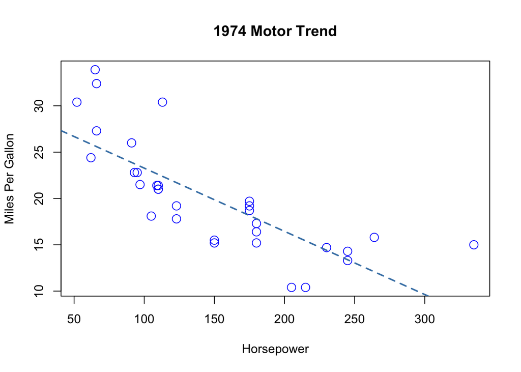

```r
plot(x = mtcars$hp,
     y = mtcars$mpg,
     cex = 1.5,
     bg = 2,
     col = "blue",
     xlab = "Horsepower",
     ylab = "Miles Per Gallon",
     main = "1974 Motor Trend")
lm1 <- lm(formula = mtcars$mpg ~ mtcars$hp, data = mtcars)
abline(lm1, col = "steelblue", lty = 2, lwd = 2)
```

```r
## It shows the relationship between horsepower and mpg is that when horsepower increases, mpg tends to decrease. It follows the trend that it a downward trend.
```

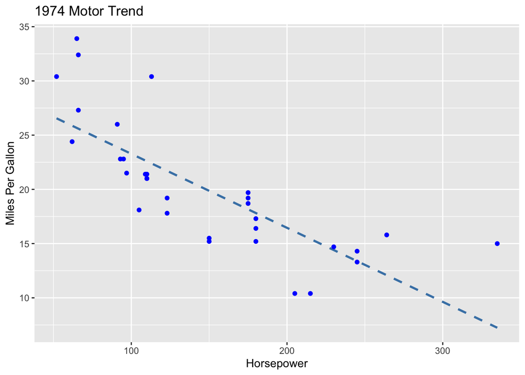

```r
mtcars %>%
  ggplot(aes(x = hp, y = mpg)) +
  geom_smooth(method = "lm", formula = y~x, se = FALSE,
              color = "steelblue", linetype = "dashed") +
  geom_point(cex = 1.5, col = "blue") +
  xlab("Horsepower") +
  ylab("Miles Per Gallon") +
  ggtitle("1974 Motor Trend")
```

## 3. Make a conditional violin plot with superimposed boxplots in ggplot2 of miles per gallon conditional on transition type (automatic or not). Interpret the plot in context.

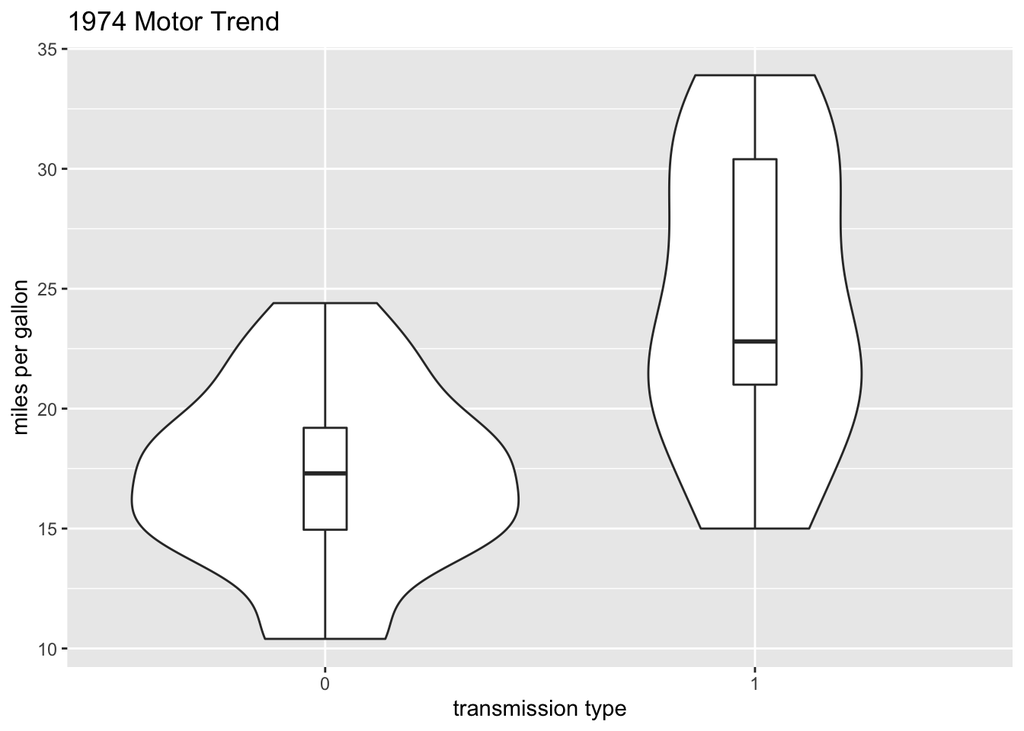

```r
mtcars %>%
  ggplot(aes(x = factor(am), y = mpg)) +
  geom_violin() +
  geom_boxplot(width = .1)  +
  xlab("transmission type") +
  ylab("miles per gallon") +
  ggtitle("1974 Motor Trend")
```

```r
## the plot has shown different types of eith automatic transmission or manual transmission. The 0 represents automatic transmission, which has a higher density on its median point in which it can make to 17.5 miles per gallon during its transmission. And for the manual transmission, it has almost 22.5 miles per gallon during its manual transmission and most of the data are gathered around 22.5. It can be told that automatic and manual transmission have the different trend of mpg.
```